# Credit Score Card

Load functions and libraries

```r
source("../code/helper_functions.R")
LoadPackages(c("dplyr", "smbinning", "stringr", "ggplot2", "forcats",
                "tibble", "gmodels", "vcd", "caret", "gridExtra", "tidyr"))
select <- dplyr::select
```

Read in data

```r
rejects2 <- readRDS("../data/rejects_v2.rds")
accepts2 <- readRDS("../data/accepts_v2.rds")
train <- readRDS("../data/train.rds")
test <- readRDS("../data/test.rds")
```

Create variable “good” bc smbinning expects it

```r
train$good = abs(as.numeric(train$GB) - 2)
train <- train %>% select(GB, good, everything())
test$good = abs(as.numeric(test$GB) - 2)
test <- test %>% select(GB, good, everything(), -id)
```

Bin variables into categories and calculate WOE values

```r
# col names of numeric predictor variables
num_names <- names(train )[sapply(train, is.numeric)]
num_names <- num_names[3:length(num_names)]
sm_result1 <- sig_bins(df = train,
                       col_names = num_names,
                       numeric = T,
                       good_col = "good")
```

[output not shown]

```
[1] "CHILDREN has iv less than .1"
```

[output not shown]

```
[1] "PERS_H has splits created"
```

[output not shown]

```
[1] "AGE has splits created"
```

[output not shown]

```
[1] "TMADD has iv less than .1"
```

[output not shown]

```
[1] "TMJOB1 has splits created"
```

[output not shown]

```
[1] "INCOME has splits created"
[1] "LOANS has no sig splits"
[1] "CASH has no sig splits"
```

[output not shown]

```
[1] "cash_per_pers has iv less than .1"
[1] "cash_per_adult has no sig splits"
```

[output not shown]

```
[1] "income_per_pers has splits created"
```

[output not shown]

```
[1] "income_per_adult has splits created"
```

[output not shown]

```
[1] "income_cash_ratio has splits created"
[1] "total_loans has no sig splits"
```

```r
# col names of factor predictor variables
factor_names <- names(train)[sapply(train, is.factor)]
factor_names <- factor_names[2:length(factor_names)]
sm_result2 <- sig_bins(df = train,
                       col_names = factor_names,
                       numeric = F,
                       good_col = "good")
```

[output not shown]

```
[1] "TITLE has iv less than .1"
```

[output not shown]

```
[1] "TEL has iv less than .1"
```

[output not shown]

```
[1] "NMBLOAN has iv less than .1"
```

[output not shown]

```
[1] "FINLOAN has iv less than .1"
```

[output not shown]

```
[1] "EC_CARD has splits created"
```

[output not shown]

```
[1] "STATUS has splits created"
```

[output not shown]

```
[1] "BUREAU has iv less than .1"
```

[output not shown]

```
[1] "LOCATION has iv less than .1"
```

[output not shown]

```
[1] "REGN has iv less than .1"
```

[output not shown]

```
[1] "DIV has iv less than .1"
```

[output not shown]

```
[1] "PRODUCT has iv less than .1"
```

[output not shown]

```
[1] "RESID has iv less than .1"
```

[output not shown]

```
[1] "NAT has iv less than .1"
```

[output not shown]

```
[1] "PROF has iv less than .1"
```

[output not shown]

```
[1] "CAR has iv less than .1"
```

[output not shown]

```
[1] "CARDS has splits created"
```

[output not shown]

```
[1] "TMADD_unk has iv less than .1"
```

[output not shown]

```
[1] "TMJOB1_unk has iv less than .1"
```

[output not shown]

```
[1] "RESID_unk has iv less than .1"
```

[output not shown]

```
[1] "adult has splits created"
```

Create binned variables for train and test set

```r
# numeric variables bins
train <- bin_cols(sm_result1, df = train, numeric = T)
# factor varialbes bins
train <- bin_cols(sm_result2, df = train, numeric = F)
# test set: numeric variables bins
test <- bin_cols(sm_result1, df = test, numeric = T)
# test set: factor varialbes bins
test <- bin_cols(sm_result2, df =test, numeric = F)
```

Generate variables for WOE values

```r
# train set: woe values for numeric variables
train <- gen_woe(sm_result1, df = train)
# train set: woe values for factor varialbes
train <- gen_woe(sm_result2, df = train)
# test set woe values for numeric variables
test <- gen_woe(sm_result1, df = test)
# test set: woe values for factor varialbes
test <- gen_woe(sm_result2, df = test)
```

Train logistic model with the signifigant WOE variables

```r
train2 <- train %>% select(GB, `_freq_`, ends_with("WOE"))
train2 <- train2 %>% select(GB,
                            `_freq_`,
                            AGE_WOE,
                            TMJOB1_WOE,
                            income_cash_ratio_WOE,
                            CARDS_WOE, adult_WOE )
# create log regression model
score_card1 <- glm(data = train2, GB ~ . -`_freq_`,
                   weights = train$`_freq_`,
                   family = "binomial",
                   control = list(maxit = 100))
# coefs, pvalues etc of model
summary(score_card1)
```

```
Call:
glm(formula = GB ~ . - `_freq_`, family = "binomial", data = train2,
    weights = train$`_freq_`, control = list(maxit = 100))

Deviance Residuals:
    Min       1Q   Median       3Q      Max
-3.0780  -1.1533  -0.4792   2.4359   3.3458

Coefficients:
                      Estimate Std. Error z value             Pr(>|z|)
(Intercept)           -3.44124    0.03448 -99.803 < 0.0000000000000002 ***
AGE_WOE               -0.68365    0.05946 -11.497 < 0.0000000000000002 ***
TMJOB1_WOE            -0.60800    0.09007  -6.751  0.00000000001473142 ***
income_cash_ratio_WOE -0.46720    0.10628  -4.396  0.00001102988758777 ***
CARDS_WOE             -0.74202    0.10417  -7.123  0.00000000000105282 ***
adult_WOE             -0.62889    0.08029  -7.833  0.00000000000000476 ***
---
Signif. codes:  0 ‘***’ 0.001 ‘**’ 0.01 ‘*’ 0.05 ‘.’ 0.1 ‘ ’ 1

(Dispersion parameter for binomial family taken to be 1)

    Null deviance: 9167.5  on 2099  degrees of freedom
Residual deviance: 8503.1  on 2094  degrees of freedom
AIC: 8515.1

Number of Fisher Scoring iterations: 5
```

Evaluate performance of model on test set

```r
# predict on test set (used by smbinnin.metrics)
test$pred <- predict(score_card1, newdata=test, type='response')
# cast as numeric (bc smbinning needs numeric)
test$GB <- as.character(test$GB) %>% as.numeric()
# model performance on test set
smbinning.metrics(dataset = test, prediction = "pred",
                  actualclass = "GB", report = 1)
```

```
  Overall Performance Metrics
  --------------------------------------------------
                    KS : 0.3556 (Fair)
                   AUC : 0.7026 (Fair)

  Classification Matrix
  --------------------------------------------------
           Cutoff (>=) : 0.0286 (Optimal)
   True Positives (TP) : 341
  False Positives (FP) : 157
  False Negatives (FN) : 131
   True Negatives (TN) : 271
   Total Positives (P) : 472
   Total Negatives (N) : 428

  Business/Performance Metrics
  --------------------------------------------------
      %Records>=Cutoff : 0.5533
             Good Rate : 0.6847 (Vs 0.5244 Overall)
              Bad Rate : 0.3153 (Vs 0.4756 Overall)
        Accuracy (ACC) : 0.6800
     Sensitivity (TPR) : 0.7225
 False Neg. Rate (FNR) : 0.2775
 False Pos. Rate (FPR) : 0.3668
     Specificity (TNR) : 0.6332
       Precision (PPV) : 0.6847
  False Discovery Rate : 0.3153
    False Omision Rate : 0.3259
  Inv. Precision (NPV) : 0.6741

  Note: 0 rows deleted due to missing data.
```

REJECTS SET: Created binned variables

```r
# numeric variables bins
rejects_scored <- bin_cols(sm_result1, df = rejects2, numeric = T)
# factor varialbes bins
rejects_scored <- bin_cols(sm_result2, df =rejects_scored, numeric = F)
```

REJECTS SET: Generate WOE values

```r
# woe values for numeric variables
rejects_scored <- gen_woe(sm_result1, df = rejects_scored)
# woe values for factor varialbes
rejects_scored <- gen_woe(sm_result2, df = rejects_scored)
```

Infer labels and weights on rejects set - Parcelling

```r
# # numeric variables bins
# accepts_scored <- bin_cols(sm_result1, df = accepts2, numeric = T)
# # factor varialbes bins
# accepts_scored <- bin_cols(sm_result2, df = accepts_scored, numeric = F)
#
# # woe values for numeric variables
# accepts_scored <- gen_woe(sm_result1, df = accepts_scored)
# # woe values for factor varialbes
# accepts_scored <- gen_woe(sm_result2, df = accepts_scored)
#
#
# rejects_scored <- allocate_points(mod = score_card1, df = rejects_scored,
#                                   pdo = 50, score = 500, odds = 20)
#
# accepts_scored <- allocate_points(mod = score_card1, df = accepts_scored,
#                                   pdo = 50, score = 500, odds = 20)
#
# parc <- seq(375, 725, 25)
#
# accepts_scored$Score_parc <- cut(accepts_scored$Score, breaks = parc)
# rejects_scored$Score_parc <- cut(rejects_scored$Score, breaks = parc)
#
# table(accepts_scored$Score_parc, accepts_scored$GB)
#
# parc_perc <- table(accepts_scored$Score_parc,
#                    accepts_scored$GB)[,2]/rowSums(table(accepts_scored$Score_parc,
#                                                         accepts_scored$GB))
#
# rejects2$GB <- 0
#
# rej_bump <- 1.25
#
# for(i in 1:(length(parc)-1)) {
#   for(j in 1:length(rejects_scored$Score)) {
#     if((rejects_scored$Score[j] > parc[i]) &
#        (rejects_scored$Score[j] <= parc[i+1]) &
#        (runif(n = 1, min = 0, max = 1) < (rej_bump*parc_perc[i]))) {
#       rejects2$GB[j] <- 1
#     }
#   }
# }
#
# table(rejects_scored$Score_parc, rejects2$GB)
#
# # add weights so that its good:bad is proportional to accepts
# rejects2$`_freq_` <- ifelse(rejects2$GB == 1, 1, 30)
# # addjust weights for accepts set so it's proportional to rejects
# accepts2$`_freq_` <- accepts2$`_freq_` * 3
#
# #New Combined Data Set
# comb_parc <- rbind(accepts2, rejects2 %>% select(names(accepts2)))
```

Infer labels and weights on rejects set - Hard Cutoff

```r
# predict prob on reject set
rejects_scored$pred <- predict(score_card1, newdata=rejects_scored,
                               type='response')
# label 1 or 0 based on optimum cutoff from smbinnimg report
rejects2$GB <- as.numeric(rejects_scored$pred > 0.0286)
# add weights based of 75% acceptance rate and 30:1 odds for bad:good
rejects2$`_freq_` <- ifelse(rejects2$GB == 1, 2, 60)
# addjust weights for accepts set so it's proportional to rejects
accepts2$`_freq_` <- accepts2$`_freq_` * 3
# combine the accepts and rejects sets
comb <- rbind(accepts2, rejects2)
```

Split the combined set to train and test

```r
set.seed(8888)
train_id <- createDataPartition(y = comb$`_freq`, p = .7, list = F)
train_comb <- comb[train_id, ]
test_comb <- comb[-train_id, ]
# create good variable and reorder cols (smbin needs same order and good var)
test_comb$good <- abs(as.numeric(test_comb$GB) - 2)
test_comb <- test_comb %>% select(GB, `_freq_`, good, everything())
train_comb$good <- abs(as.numeric(train_comb$GB) - 2)
train_comb <- train_comb %>% select(GB, `_freq_`, good, everything())
```

Bin variables into categories and calculate WOE values based on train_comb set

```r
# col names of numeric predictor variables
num_names <- names(train_comb )[sapply(train_comb, is.numeric)]
num_names <- num_names[4:length(num_names)]
sm_result3 <- sig_bins(df = train_comb,
                       col_names = num_names,
                       numeric = T,
                       good_col = "good")
```

[output not shown]

```
[1] "CHILDREN has iv less than .1"
```

[output not shown]

```
[1] "PERS_H has splits created"
```

[output not shown]

```
[1] "AGE has splits created"
```

[output not shown]

```
[1] "TMADD has splits created"
```

[output not shown]

```
[1] "TMJOB1 has splits created"
[1] "INCOME has no sig splits"
```

[output not shown]

```
[1] "LOANS has iv less than .1"
[1] "CASH has no sig splits"
[1] "cash_per_pers has no sig splits"
[1] "cash_per_adult has no sig splits"
```

[output not shown]

```
[1] "income_per_pers has splits created"
```

[output not shown]

```
[1] "income_per_adult has splits created"
```

[output not shown]

```
[1] "income_cash_ratio has splits created"
```

[output not shown]

```
[1] "total_loans has iv less than .1"
```

```r
# col names of factor predictor variables
factor_names <- names(train_comb)[sapply(train_comb, is.factor)]
factor_names <- factor_names[2:length(factor_names)]
sm_result4 <- sig_bins(df = train_comb,
                       col_names = factor_names,
                       numeric = F,
                       good_col = "good")
```

[output not shown]

```
[1] "TITLE has iv less than .1"
```

[output not shown]

```
[1] "TEL has iv less than .1"
```

[output not shown]

```
[1] "NMBLOAN has iv less than .1"
```

[output not shown]

```
[1] "FINLOAN has iv less than .1"
```

[output not shown]

```
[1] "EC_CARD has splits created"
```

[output not shown]

```
[1] "STATUS has splits created"
```

[output not shown]

```
[1] "BUREAU has iv less than .1"
```

[output not shown]

```
[1] "LOCATION has iv less than .1"
```

[output not shown]

```
[1] "REGN has iv less than .1"
```

[output not shown]

```
[1] "DIV has iv less than .1"
```

[output not shown]

```
[1] "PRODUCT has iv less than .1"
```

[output not shown]

```
[1] "RESID has iv less than .1"
```

[output not shown]

```
[1] "NAT has iv less than .1"
```

[output not shown]

```
[1] "PROF has iv less than .1"
```

[output not shown]

```
[1] "CAR has iv less than .1"
```

[output not shown]

```
[1] "CARDS has splits created"
```

[output not shown]

```
[1] "TMADD_unk has iv less than .1"
```

[output not shown]

```
[1] "TMJOB1_unk has iv less than .1"
```

[output not shown]

```
[1] "RESID_unk has iv less than .1"
```

[output not shown]

```
[1] "adult has splits created"
```

Train set: Create binned variables and WOE values

```r
# numeric variables bins
train_comb <- bin_cols(sm_result3, df = train_comb, numeric = T)
# factor varialbes bins
train_comb <- bin_cols(sm_result4, df = train_comb, numeric = F)
# woe values for numeric variables
train_comb <- gen_woe(sm_result3, df = train_comb)
# woe values for factor varialbes
train_comb <- gen_woe(sm_result4, df = train_comb)
```

Adjust bands to test set

```r
for(i in names(sm_result3)) {
  sm_result3[[i]]$bands[1] <- min(test_comb[[i]], na.rm = TRUE)
  sm_result3[[i]]$bands[length(sm_result3[[i]]$bands)] <- max(test_comb[[i]],
                                                                na.rm = TRUE)
}
```

Test set: Create binned variables and generate variables WOE values

```r
# add a copy of obs with motorbike from train set into test set
# bc test set doesn't have one and caused error with smbinning gen
# should have one hot encodedeverything from the start
dupe_obs <- train_comb %>% filter(CAR == 'Motorbike') %>% slice(1)
test_comb <- bind_rows(test_comb, dupe_obs %>% select(names(test_comb)))
# numeric variables bins
test_comb <- bin_cols(sm_result3, df = test_comb, numeric = T)
# factor varialbes bins
test_comb <- bin_cols(sm_result4, df = test_comb, numeric = F)
# woe values for numeric variables
test_comb <- gen_woe(sm_result3, df = test_comb)
# woe values for factor varialbes
test_comb <- gen_woe(sm_result4, df = test_comb)
```

Train logistic model with the signifigant WOE variables

```r
train_comb2 <- train_comb %>% select(GB, `_freq_`, ends_with('WOE')) %>%
  select( -EC_CARD_WOE, -STATUS_WOE, -PERS_H_WOE,
           -income_per_pers_WOE, -income_per_adult_WOE )
score_card2 <- glm(data = train_comb2, GB ~ . -`_freq_`,
                   weights = train_comb$`_freq_`,
                   family = "binomial",
                   control = list(maxit = 100))
summary(score_card2)
```

```
Call:
glm(formula = GB ~ . - `_freq_`, family = "binomial", data = train_comb2,
    weights = train_comb$`_freq_`, control = list(maxit = 100))

Deviance Residuals:
   Min      1Q  Median      3Q     Max
-7.494  -1.593   2.660   3.701   6.085

Coefficients:
                      Estimate Std. Error  z value             Pr(>|z|)
(Intercept)           -3.23185    0.01720 -187.892 < 0.0000000000000002 ***
AGE_WOE               -0.63978    0.01890  -33.855 < 0.0000000000000002 ***
TMADD_WOE             -0.34070    0.04637   -7.347    0.000000000000202 ***
TMJOB1_WOE            -0.53487    0.02994  -17.865 < 0.0000000000000002 ***
income_cash_ratio_WOE -0.15469    0.05305   -2.916              0.00355 **
CARDS_WOE             -0.86225    0.05121  -16.837 < 0.0000000000000002 ***
adult_WOE             -0.49076    0.02917  -16.825 < 0.0000000000000002 ***
---
Signif. codes:  0 ‘***’ 0.001 ‘**’ 0.01 ‘*’ 0.05 ‘.’ 0.1 ‘ ’ 1

(Dispersion parameter for binomial family taken to be 1)

    Null deviance: 38489  on 3150  degrees of freedom
Residual deviance: 33706  on 3144  degrees of freedom
AIC: 33720

Number of Fisher Scoring iterations: 6
```

Evaluate performance of model on test set

```r
# predict on test set
test_comb$pred <- predict(score_card2, newdata=test_comb, type='response')
# cast as numeric (bc smbinning needs numeric)
test_comb$GB <- as.character(test_comb$GB) %>% as.numeric()
# model performance on test set
smbinning.metrics(dataset = test_comb, prediction = "pred",
                  actualclass = "GB", report = 1)
```

```
  Overall Performance Metrics
  --------------------------------------------------
                    KS : 0.5041 (Excellent)
                   AUC : 0.8147 (Good)

  Classification Matrix
  --------------------------------------------------
           Cutoff (>=) : 0.0391 (Optimal)
   True Positives (TP) : 529
  False Positives (FP) : 127
  False Negatives (FN) : 213
   True Negatives (TN) : 481
   Total Positives (P) : 742
   Total Negatives (N) : 608

  Business/Performance Metrics
  --------------------------------------------------
      %Records>=Cutoff : 0.4859
             Good Rate : 0.8064 (Vs 0.5496 Overall)
              Bad Rate : 0.1936 (Vs 0.4504 Overall)
        Accuracy (ACC) : 0.7481
     Sensitivity (TPR) : 0.7129
 False Neg. Rate (FNR) : 0.2871
 False Pos. Rate (FPR) : 0.2089
     Specificity (TNR) : 0.7911
       Precision (PPV) : 0.8064
  False Discovery Rate : 0.1936
    False Omision Rate : 0.3069
  Inv. Precision (NPV) : 0.6931

  Note: 0 rows deleted due to missing data.
```

Combine train and test set

```r
train_comb$set <- "train"
train_comb$GB <- as.character(train_comb$GB) %>% as.numeric()
test_comb$set <- "test"
all_scored <- bind_rows(train_comb, test_comb %>%
                          select(names(train_comb))) %>%
  as.data.frame()
```

Generate scores, buckets for the scores and predicted probabilities

```r
# generate a score for each person
all_scored <- allocate_points(mod = score_card2, df = all_scored,
                              pdo = 50, score = 500, odds = 20)
# create buckets / categories for the scores
all_scored$buckets <- cut(all_scored$Score, breaks = c(seq(300, 750, 50)))
# create predicted probabilities for each person
all_scored$pred <- predict(score_card2, newdata=all_scored, type='response')
```

Create the acutal score card

| bin | points | var |
| --- | --- | --- |
| 01 <= 22 | 10 | AGE_bin |
| 02 <= 27 | 50 | AGE_bin |
| 03 <= 35 | 93 | AGE_bin |
| 04 <= 45 | 112 | AGE_bin |
| 05 > 45 | 158 | AGE_bin |
| 01 <= 21 | 74 | TMADD_bin |
| 02 > 21 | 91 | TMADD_bin |
| 01 <= 18 | 58 | TMJOB1_bin |
| 02 <= 84 | 85 | TMJOB1_bin |
| 03 <= 158.072 | 114 | TMJOB1_bin |

[output cut: 11 more lines]

Adjust observations for the weights

```r
# duplicate rows based on the freq / weight column so that it's a representative
# sample of applicants
scored_adj <- all_scored[rep(seq_along(all_scored$`_freq_`),
                             all_scored$`_freq_`), ]
```

Average predicted probability and bad rate for each score bucket

```r
# average prob for each score bucket
score_bucket <- scored_adj %>%
  group_by(buckets) %>%
  summarize("Avg Probability" = mean(pred), count = n(),
            bad_n = sum(GB) , "Default Rate" = bad_n / count) %>%
  mutate(buckets = str_replace_all(buckets,",", ", ")) %>%
  select(buckets, "Avg Probability", "Default Rate") %>%
  gather(key, value, -buckets)
```

Bar charts of default probability and rate by score

```
Ignoring unknown parameters: stat
```

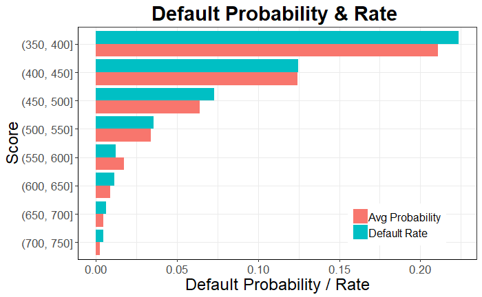

```r
ggplot(score_bucket, aes(x = fct_rev(buckets), y = value, fill = factor(key))) +
  geom_col(stat = "identity", position = "dodge") +
  coord_flip() +
  labs(title = "Default Probability & Rate ",
       x = "Score",
       y = "Default Probability / Rate") +
  theme_bw() +
  theme(plot.title = element_text(hjust = .5, size = 22, face = "bold"),
        axis.text=element_text(size=13),
        axis.title=element_text(size=18),
        axis.line = element_line(colour = "black"),
        legend.text=element_text(size=12),
        legend.title = element_blank(),
        legend.position = c(.8,.15))
```

Picking a cut off score

| cutoff | accepts_n | bad_n | good_n | total_n | accepts_per | bad_per | good_rev | bad_cost | profit | profit_per_cust | profit_per_accept |
| --- | --- | --- | --- | --- | --- | --- | --- | --- | --- | --- | --- |
| 400 | 50789 | 1709 | 49080 | 51922 | 97.81788 | 3.3649018 | 98160000 | -88868000 | 9292000 | 178.9607 | 182.9530 |
| 401 | 50789 | 1709 | 49080 | 51922 | 97.81788 | 3.3649018 | 98160000 | -88868000 | 9292000 | 178.9607 | 182.9530 |
| 402 | 50390 | 1580 | 48810 | 51922 | 97.04942 | 3.1355428 | 97620000 | -82160000 | 15460000 | 297.7543 | 306.8069 |
| 403 | 50390 | 1580 | 48810 | 51922 | 97.04942 | 3.1355428 | 97620000 | -82160000 | 15460000 | 297.7543 | 306.8069 |
| 404 | 50288 | 1568 | 48720 | 51922 | 96.85297 | 3.1180401 | 97440000 | -81536000 | 15904000 | 306.3056 | 316.2584 |
| 405 | 50288 | 1568 | 48720 | 51922 | 96.85297 | 3.1180401 | 97440000 | -81536000 | 15904000 | 306.3056 | 316.2584 |
| 406 | 50288 | 1568 | 48720 | 51922 | 96.85297 | 3.1180401 | 97440000 | -81536000 | 15904000 | 306.3056 | 316.2584 |
| 407 | 50288 | 1568 | 48720 | 51922 | 96.85297 | 3.1180401 | 97440000 | -81536000 | 15904000 | 306.3056 | 316.2584 |
| 408 | 50288 | 1568 | 48720 | 51922 | 96.85297 | 3.1180401 | 97440000 | -81536000 | 15904000 | 306.3056 | 316.2584 |
| 409 | 50193 | 1563 | 48630 | 51922 | 96.67001 | 3.1139800 | 97260000 | -81276000 | 15984000 | 307.8464 | 318.4508 |

[output cut: 191 more lines]

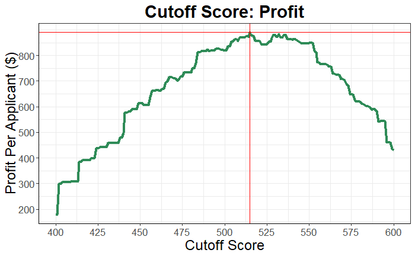

```r
ggplot(cutoffs, aes(x= cutoff, y = profit_per_cust)) +
  geom_line(size = 1.5, color = "seagreen") +
  geom_hline(yintercept = max_profit, color = 'red') +
  geom_vline(xintercept = opt_cut, color = 'red') +
  labs(title = "Cutoff Score: Profit",
       x = "Cutoff Score",
       y = "Profit Per Applicant ($)") +
  theme_bw() +
  theme(plot.title = element_text(hjust = .5, size = 22, face = "bold"),
        axis.text=element_text(size=13),
        axis.title=element_text(size=18),
        axis.line = element_line(colour = "black")) +
  scale_x_continuous( breaks = c(seq(400,600, 25))) +
  scale_y_continuous( breaks = c(seq(200,800, 100)))
```

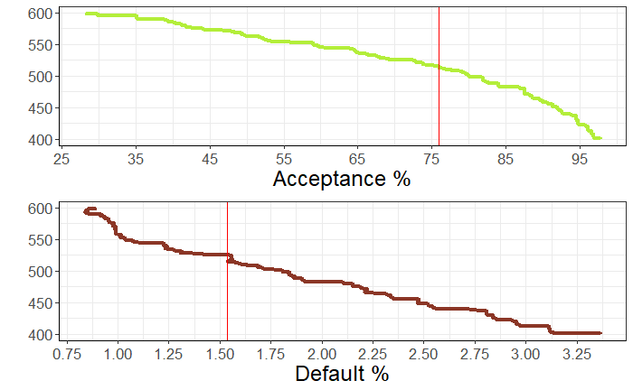

```r
p1 <- ggplot(cutoffs, aes(x= cutoff, y = accepts_per)) +
  geom_line(size = 1.5, color = "olivedrab2") +
  coord_flip() +
  geom_hline(yintercept = opt_acpt, color = 'red') +
  labs(x = "",
       y = "Acceptance %") +
  theme_bw() +
  theme(plot.title = element_text(hjust = .5, size = 22, face = "bold"),
        axis.text=element_text(size=13),
        axis.title=element_text(size=18),
        axis.line = element_line(colour = "black")) +
  scale_x_continuous( breaks = c(seq(400,600, 50))) +
  scale_y_continuous( breaks = c(seq(25,100, 10)))
p2 <- ggplot(cutoffs, aes(x= cutoff, y = bad_per)) +
  geom_line(size = 1.5, color = "tomato4") +
  coord_flip() +
  geom_hline(yintercept = opt_bad, color = 'red') +
  labs(x = "",
       y = "Default %") +
  theme_bw() +
  theme(plot.title = element_text(hjust = .5, size = 22, face = "bold"),
        axis.text=element_text(size=13),
        axis.title=element_text(size=18),
        axis.line = element_line(colour = "black"))+
  scale_x_continuous( breaks = c(seq(400,600, 50))) +
  scale_y_continuous( breaks = c(seq(0,3.25, .25)))
grid.arrange(p1, p2, ncol = 1)
```

Confusion Matrix for unadjusted test set using score cutoff

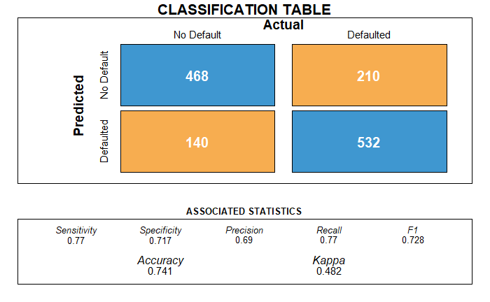

```r
test_scored2 <- all_scored %>%
  filter(set == "test") %>%
  mutate(pred_cut = ifelse(Score > 519, 0,1)) %>%
  select(GB, pred_cut, Score, everything())
cm <- confusionMatrix(data = as.factor(test_scored2$pred_cut),
                reference = as.factor(test_scored2$GB))
draw_confusion_matrix(cm)
```

Confusion Matrix for adjusted test set using score cutoff

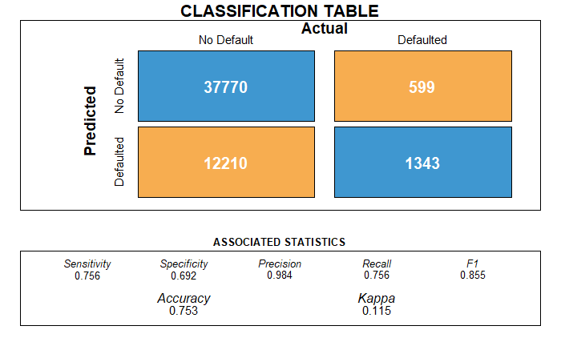

```r
test_scored <- test_scored %>%
  mutate(pred_cut = ifelse(Score > 519, 0,1)) %>%
  select(GB, pred_cut, Score, everything())
cm <- confusionMatrix(data = as.factor(test_scored$pred_cut),
                reference = as.factor(test_scored$GB))
draw_confusion_matrix(cm)
```

```r
profit_per_applicant
```

```
[1] 191.8499
```